# IODS course project

Retu Haikonen

# Introduction to Open Data Science - Course Project

This is overall view of the course updating weekly, so stay tuned.

# About the project

```r
# This is a so-called "R chunk" where you can write R code.

date()
```

```
## [1] "Mon Dec 13 09:22:37 2021"
```

HeyHeyHey, this is my course page. Hopefully this course will bring new knowledge to all the participants.

To whom it might concern, my GitHub repository can be found under the link down below:

[GitHub/RetuWonData](https://github.com/RetuWonData/IODS-project)

Hope you find is as interesting as I do.

Cheers, Retu

# Chapter 2: Simple regression and model validation

- Describe your work and results clearly.
- Assume the reader has an introductory course level understanding of writing and reading R code as well as statistical methods.
- Assume the reader has no previous knowledge of your data or the more advanced methods you are using.

```r
learning <- read.csv("data/learning2014.csv",header = T)
str(learning)
```

```
## 'data.frame':    166 obs. of  7 variables:
##  $ gender  : chr  "F" "M" "F" "M" ...
##  $ age     : int  53 55 49 53 49 38 50 37 37 42 ...
##  $ attitude: num  3.7 3.1 2.5 3.5 3.7 3.8 3.5 2.9 3.8 2.1 ...
##  $ deep    : num  3.58 2.92 3.5 3.5 3.67 ...
##  $ stra    : num  3.38 2.75 3.62 3.12 3.62 ...
##  $ surf    : num  2.58 3.17 2.25 2.25 2.83 ...
##  $ points  : int  25 12 24 10 22 21 21 31 24 26 ...
```

Here you can see some structures of the data. As demonstrated, we have 166 observation containing 7 different variables. Gender is in this case binomial containing M (Male) and F (Female). Age (in years) is derived from the date of birth. Attitude describes global attitude toward statistics and it is the mean of several observation. Variables deep, stra and surf are describing the averages from different questions. The last variable points is the number of points from the exam.

Here is some figures showing some of the important findings from this study.

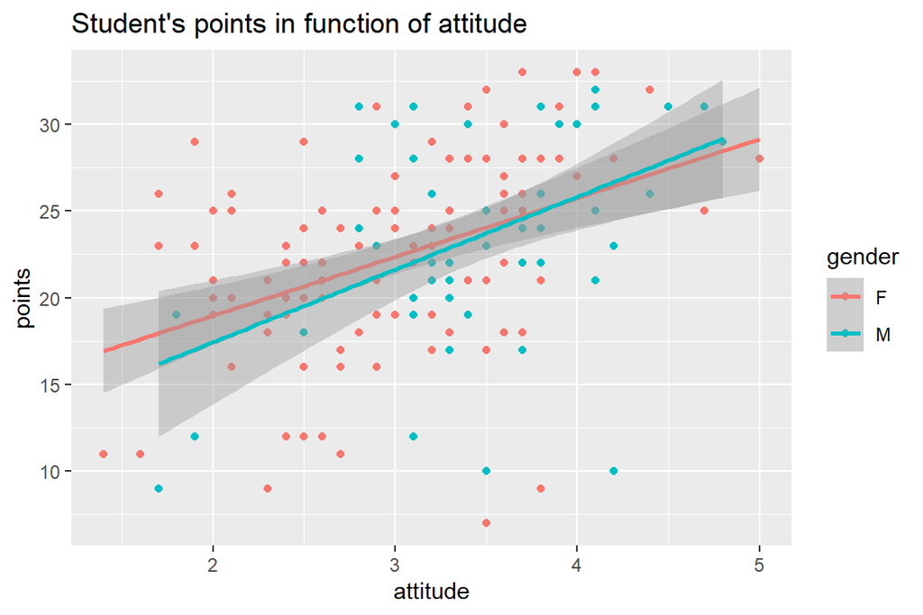

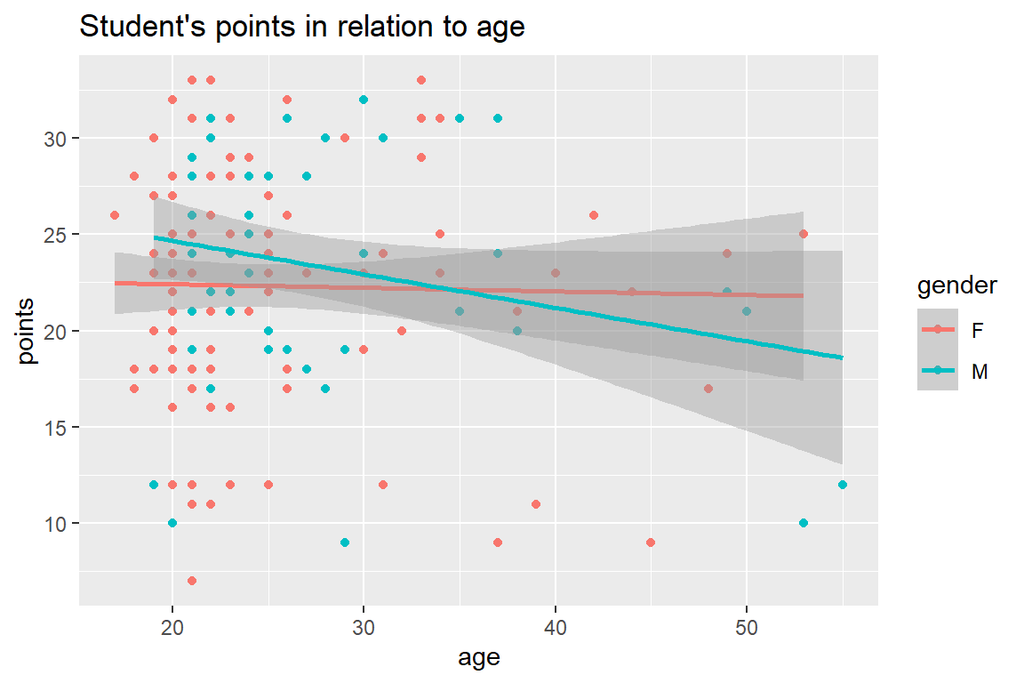

```r
library(ggplot2)
# initialize plot with data and aesthetic mapping
ggplot(learning, aes(x = attitude, y = points, col = gender))+
  geom_point()+
  geom_smooth(method = "lm")+
  ggtitle("Student's points in function of attitude")
ggplot(learning, aes(x = age, y = points, col = gender))+
  geom_point()+
  geom_smooth(method = "lm")+
  ggtitle("Student's points in relation to age")
```

These two relationship shown above seems to be rather interesting. Surprisingly or not, if the attitude is better the learning outcome is better. Additionally, higher age correlates with lower learning outcome, especially for male. On the other hand plots below are not that interesting although they demonstrate the different between sex.

[figure not shown]

[figure not shown]

```r
library(ggplot2)

# initialize plot with data and aesthetic mapping
ggplot(learning, aes(x = surf, y = points, col = gender))+
  geom_point()+
  geom_smooth(method = "lm")+
  ggtitle("Student's points in function of attitude")
ggplot(learning, aes(x = deep, y = points, col = gender))+
  geom_point()+
  geom_smooth(method = "lm")+
  ggtitle("Student's points in function of attitude")
```

And below we have numerical summary.

```r
summary(learning)
```

```
##     gender               age           attitude          deep
##  Length:166         Min.   :17.00   Min.   :1.400   Min.   :1.583
##  Class :character   1st Qu.:21.00   1st Qu.:2.600   1st Qu.:3.333
##  Mode  :character   Median :22.00   Median :3.200   Median :3.667
##                     Mean   :25.51   Mean   :3.143   Mean   :3.680
##                     3rd Qu.:27.00   3rd Qu.:3.700   3rd Qu.:4.083
##                     Max.   :55.00   Max.   :5.000   Max.   :4.917
##       stra            surf           points
##  Min.   :1.250   Min.   :1.583   Min.   : 7.00
##  1st Qu.:2.625   1st Qu.:2.417   1st Qu.:19.00
##  Median :3.188   Median :2.833   Median :23.00
##  Mean   :3.121   Mean   :2.787   Mean   :22.72
##  3rd Qu.:3.625   3rd Qu.:3.167   3rd Qu.:27.75
##  Max.   :5.000   Max.   :4.333   Max.   :33.00
```

People participating seems to be quite young and had good points overall.

Next we are going to evaluate the relationship of the variables with linear model.

```r
my_model <- lm(points ~ gender+age+attitude+deep+stra+surf, data = learning)

# summary of the model
summary(my_model)
```

```
##
## Call:
## lm(formula = points ~ gender + age + attitude + deep + stra +
##     surf, data = learning)
##
## Residuals:
##      Min       1Q   Median       3Q      Max
## -17.4506  -3.2479   0.3879   3.5243  11.4820
##
## Coefficients:
##             Estimate Std. Error t value Pr(>|t|)
## (Intercept) 18.30246    5.25723   3.481 0.000644 ***
## genderM     -0.05858    0.92985  -0.063 0.949845
## age         -0.09607    0.05396  -1.780 0.076929 .
## attitude     3.44300    0.59776   5.760 4.24e-08 ***
## deep        -1.04279    0.78438  -1.329 0.185606
## stra         0.95871    0.55150   1.738 0.084083 .
## surf        -1.10891    0.84467  -1.313 0.191132
## ---
## Signif. codes:  0 '***' 0.001 '**' 0.01 '*' 0.05 '.' 0.1 ' ' 1
##
## Residual standard error: 5.265 on 159 degrees of freedom
## Multiple R-squared:  0.2312, Adjusted R-squared:  0.2021
## F-statistic: 7.967 on 6 and 159 DF,  p-value: 1.599e-07
```

After linear modeling and statistical testing, one can see that there is not so much difference. P value of the whole model is 1.599e-07, which means there is at least one variable effecting to points value.

T-test value probabilities Pr(>|t|) describe the change in dependent value after change in explanatory variable. The cut off for significance is typically alfa = 0.05. With this cutoff attitude is the only variable inducing significant changes so fitting new model with it.

```r
my_model2 <- lm(points ~ attitude, data = learning)

# summary of the model
summary(my_model2)
```

```
##
## Call:
## lm(formula = points ~ attitude, data = learning)
##
## Residuals:
##      Min       1Q   Median       3Q      Max
## -16.9763  -3.2119   0.4339   4.1534  10.6645
##
## Coefficients:
##             Estimate Std. Error t value Pr(>|t|)
## (Intercept)  11.6372     1.8303   6.358 1.95e-09 ***
## attitude      3.5255     0.5674   6.214 4.12e-09 ***
## ---
## Signif. codes:  0 '***' 0.001 '**' 0.01 '*' 0.05 '.' 0.1 ' ' 1
##
## Residual standard error: 5.32 on 164 degrees of freedom
## Multiple R-squared:  0.1906, Adjusted R-squared:  0.1856
## F-statistic: 38.61 on 1 and 164 DF,  p-value: 4.119e-09
```

In this model estimates are about 11.6 and 3.52 meaning that value of dependant variable is 11.6 when explanatory variable is x = 0. Estimate of attitude tells that dependant variable increase 3.52 ‘points’ when attitude increase by 1.

Multiple R-squared is 0.19 meaning that residuals are quite big and that this model is not nessesary the best for this data. To get better look of residuals several visualization can be done.

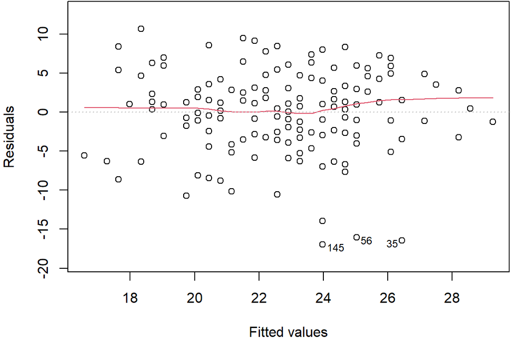

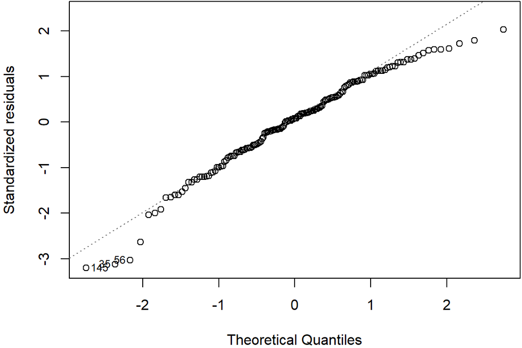

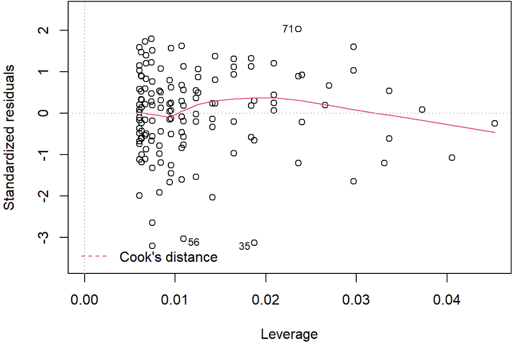

```r
par(mar = c(4, 4, .1, .1))
# par(mfrow = c(2,2))
plot(my_model2, which = c(1,2,5))
```

Assumptions related to linear model are obviously linearity and that the distribution is normally distributed. The model follows normality assumption quite good as can be seen from QQ-plot. Furthermore, there is a constant variance in errors as can be seen in residual plot and non of the points have unusually high leverage to the model. As a sum up, the model describes the relationship between points and attitude quite good.

Back to top

# Chapter 3: Logistic regression

## Data

```r
setwd("~/Tilastotiede/IODS-project")
alc <- read.csv(file = "data/alc.csv", row.names = 1)
dim(alc)
```

```
## [1] 370  51
```

```r
colnames(alc)
```

```
##  [1] "school"     "sex"        "age"        "address"    "famsize"
##  [6] "Pstatus"    "Medu"       "Fedu"       "Mjob"       "Fjob"
## [11] "reason"     "guardian"   "traveltime" "studytime"  "schoolsup"
## [16] "famsup"     "activities" "nursery"    "higher"     "internet"
## [21] "romantic"   "famrel"     "freetime"   "goout"      "Dalc"
## [26] "Walc"       "health"     "n"          "id.p"       "id.m"
## [31] "failures"   "paid"       "absences"   "G1"         "G2"
## [36] "G3"         "failures.p" "paid.p"     "absences.p" "G1.p"
## [41] "G2.p"       "G3.p"       "failures.m" "paid.m"     "absences.m"
## [46] "G1.m"       "G2.m"       "G3.m"       "alc_use"    "high_use"
## [51] "cid"
```

This data is from Portuguese secondary school and it describes the alcohol consumption habits. It was collected by using questionnaires and school reports. Here we have combined data set and they represent performing in Mathematics and Portuguese language.

More information can be found from [here](https://archive.ics.uci.edu/ml/datasets/Student+Performance).

## Hypothesis

If I have to guess Ill take these four variables that could explain high alcohol consumption. Below there is some thoughts why. *goout - going out with friends (numeric: from 1 - very low to 5 - very high) - Typically if one is going out often alcohol may play some role.* studytime - weekly study time (numeric: 1 - <2 hours, 2 - 2 to 5 hours, 3 - 5 to 10 hours, or 4 - >10 hours) - If one is studing more often the alcohol consumption is lover. *G3 - final grade (numeric: from 0 to 20, output target) - Final grade is often good if one havent drink so much* absences - number of school absences (numeric: from 0 to 93) - Typically people that are not often seen at school are more often seen at bar.

Back to top

## Distribution and relationships

Here one can find correlation plot. I wanted to look hypothesized variables and some extras to see is there any better variables but not too many to keep plot easy to understand.

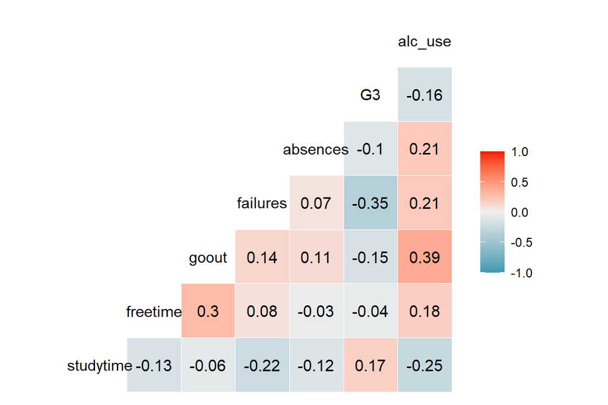

```r
library(GGally)
ggcorr(alc[colnames(alc) %in% c("goout", "absences", "G3", "freetime", "studytime", "failures", "alc_use")],
       palette = "RdBu", label = TRUE, label_round=2)
```

Free time shows good correlation but I will keep the hypothesized variables as they all show good correlation.

As we are going to use binary variable high_use here are some box plot.

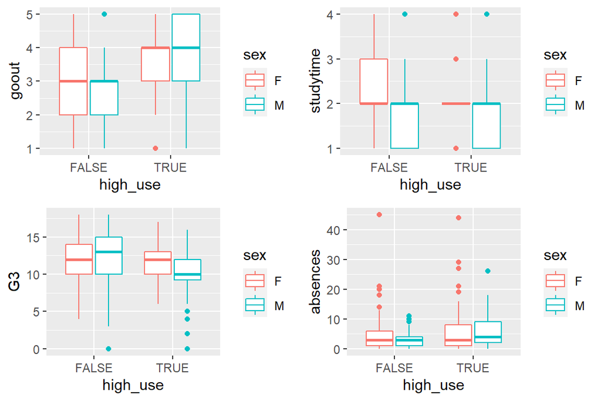

```r
library(cowplot)
g1 <- ggplot(alc, aes(x = high_use, y = goout, col = sex)) +
  geom_boxplot()
g2 <- ggplot(alc, aes(x = high_use, y = studytime, col = sex)) +
  geom_boxplot()
g3 <- ggplot(alc, aes(x = high_use, y = G3, col = sex)) +
  geom_boxplot()
g4 <- ggplot(alc, aes(x = high_use, y = absences, col = sex)) +
  geom_boxplot()

plot_grid(g1,g2,g3,g4)
```

Back to top

```r
mod <- glm(high_use ~ goout + studytime + G3 + absences , data = alc)
summary(mod)
```

```
##
## Call:
## glm(formula = high_use ~ goout + studytime + G3 + absences, data = alc)
##
## Deviance Residuals:
##     Min       1Q   Median       3Q      Max
## -0.7931  -0.2933  -0.1333   0.3560   1.0605
##
## Coefficients:
##              Estimate Std. Error t value Pr(>|t|)
## (Intercept)  0.078876   0.116565   0.677 0.499045
## goout        0.130941   0.019439   6.736 6.36e-11 ***
## studytime   -0.091461   0.025997  -3.518 0.000489 ***
## G3          -0.005319   0.006750  -0.788 0.431273
## absences     0.013570   0.003981   3.409 0.000726 ***
## ---
## Signif. codes:  0 '***' 0.001 '**' 0.01 '*' 0.05 '.' 0.1 ' ' 1
##
## (Dispersion parameter for gaussian family taken to be 0.1719535)
##
##     Null deviance: 77.700  on 369  degrees of freedom
## Residual deviance: 62.763  on 365  degrees of freedom
## AIC: 405.58
##
## Number of Fisher Scoring iterations: 2
```

```r
coef(mod)
```

```
##  (Intercept)        goout    studytime           G3     absences
##  0.078876118  0.130941177 -0.091461304 -0.005318601  0.013569779
```

```r
Odds <-coef(mod) %>% exp
Confidence <- confint(mod) %>% exp
cbind(Odds, Confidence)
```

```
##                  Odds     2.5 %    97.5 %
## (Intercept) 1.0820703 0.8610627 1.3598034
## goout       1.1399007 1.0972868 1.1841696
## studytime   0.9125966 0.8672614 0.9603018
## G3          0.9946955 0.9816217 1.0079434
## absences    1.0136623 1.0057837 1.0216026
```

Back to top

## Prediction power

```r
library(dplyr)
mod <- glm(high_use ~ goout + studytime  + absences , data = alc)

#prediction and observing the data
prob <- predict(mod, type = "response")
alc <- mutate(alc, probability = prob)
alc <- mutate(alc, prediction = probability > 0.5)
select(alc, failures, absences, studytime, high_use, probability, prediction) %>% tail(10)
```

```
##     failures absences studytime high_use  probability prediction
## 361        1        7         1     TRUE  0.417707735      FALSE
## 362        0        3         1     TRUE  0.362542445      FALSE
## 363        0        2         1     TRUE  0.082861807      FALSE
## 364        0        4         2     TRUE  0.414546108      FALSE
## 365        0        3         1    FALSE  0.229597787      FALSE
## 366        0        4         1     TRUE  0.376333767      FALSE
## 367        0        0         3    FALSE -0.001240813      FALSE
## 368        1        4         1     TRUE  0.509278425       TRUE
## 369        2        8         2     TRUE  0.469711399      FALSE
## 370        1        0         1    FALSE  0.188223820      FALSE
```

```r
table(high_use = alc$high_use, prediction = alc$prediction)
```

```
##         prediction
## high_use FALSE TRUE
##    FALSE   239   20
##    TRUE     68   43
```

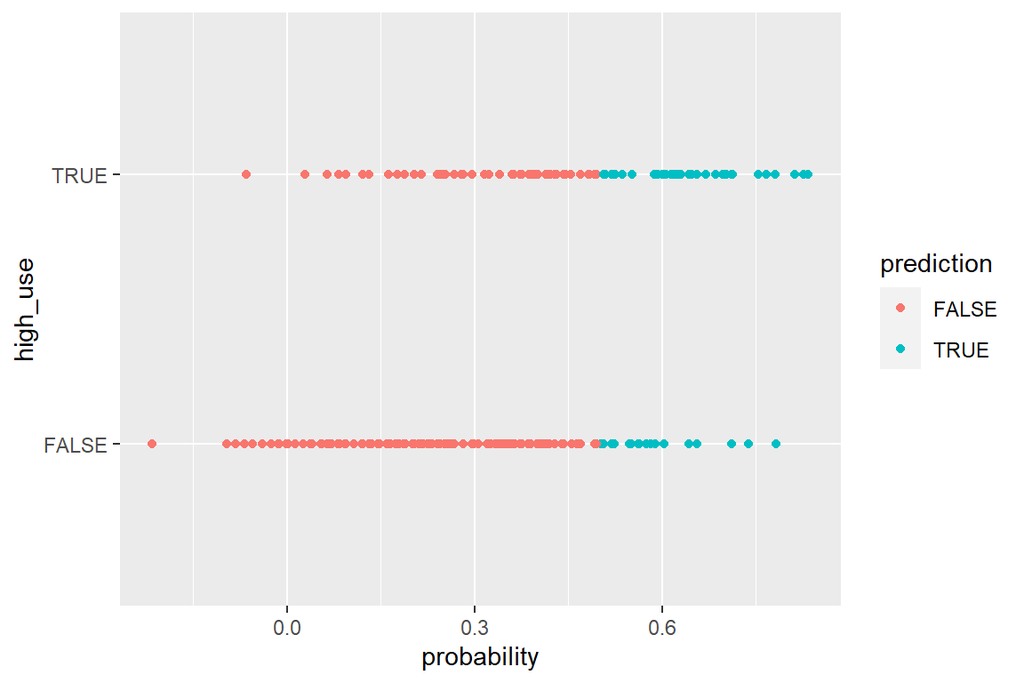

```r
g <- ggplot(alc, aes(x = probability, y = high_use, col = prediction))

# define the geom as points and draw the plot
g + geom_point()
```

```r
# tabulate the target variable versus the predictions
table(high_use = alc$high_use, prediction = alc$prediction) %>% prop.table %>% addmargins
```

```
##         prediction
## high_use      FALSE       TRUE        Sum
##    FALSE 0.64594595 0.05405405 0.70000000
##    TRUE  0.18378378 0.11621622 0.30000000
##    Sum   0.82972973 0.17027027 1.00000000
```

Results are expected, as typically this complex data set is hard to predict. Against expectations the G3 variable (grades) was not good predictor and thus dropped out.

Back to top

## Cross-validation

```r
library(boot)
toCV <- function(class, prob) {
  n_wrong <- abs(class - prob) > 0.5
  mean(n_wrong)
}

toCV(class = alc$high_use, prob = alc$probability)
```

```
## [1] 0.2378378
```

```r
cv <- cv.glm(data = alc, cost = toCV, glmfit = mod, K = 10)

# average number of wrong predictions in the cross validation
cv$delta[1]
```

```
## [1] 0.2432432
```

The number of wrong predictions is near 0.24, so very similar to simplified model evaluation.

Back to top

# Chapter 4: Clustering and classification

## Data

Loading the data and having some look of the main principles.

```r
library(dplyr)
library(ggplot2)
library(tidyr)
library(boot)
library(MASS)
library(corrplot)
data(Boston)
head(Boston)
```

```
##      crim zn indus chas   nox    rm  age    dis rad tax ptratio  black lstat
## 1 0.00632 18  2.31    0 0.538 6.575 65.2 4.0900   1 296    15.3 396.90  4.98
## 2 0.02731  0  7.07    0 0.469 6.421 78.9 4.9671   2 242    17.8 396.90  9.14
## 3 0.02729  0  7.07    0 0.469 7.185 61.1 4.9671   2 242    17.8 392.83  4.03
## 4 0.03237  0  2.18    0 0.458 6.998 45.8 6.0622   3 222    18.7 394.63  2.94
## 5 0.06905  0  2.18    0 0.458 7.147 54.2 6.0622   3 222    18.7 396.90  5.33
## 6 0.02985  0  2.18    0 0.458 6.430 58.7 6.0622   3 222    18.7 394.12  5.21
##   medv
## 1 24.0
## 2 21.6
## 3 34.7
## 4 33.4
## 5 36.2
## 6 28.7
```

```r
dim(Boston)
```

```
## [1] 506  14
```

This boston data set is contains 506 observations in 14 following variables:

crim = per capita crime rate by town.

zn = proportion of residential land zoned for lots over 25,000 sq.ft.

indus = proportion of non-retail business acres per town.

chas = Charles River dummy variable (= 1 if tract bounds river; 0 otherwise).

nox = nitrogen oxides concentration (parts per 10 million).

rm = average number of rooms per dwelling.

age = proportion of owner-occupied units built prior to 1940.

dis = weighted mean of distances to five Boston employment centres.

rad = index of accessibility to radial highways.

tax = full-value property-tax rate per $10,000.

ptratio = pupil-teacher ratio by town.

black = 1000(Bk - 0.63)^2 where Bk is the proportion of blacks by town.

lstat = lower status of the population (percent).

medv = median value of owner-occupied homes in $1000s.

Here is numerical and graphical abstract of the data.

```r
summary(Boston)
```

```
##       crim                zn             indus            chas
##  Min.   : 0.00632   Min.   :  0.00   Min.   : 0.46   Min.   :0.00000
##  1st Qu.: 0.08205   1st Qu.:  0.00   1st Qu.: 5.19   1st Qu.:0.00000
##  Median : 0.25651   Median :  0.00   Median : 9.69   Median :0.00000
##  Mean   : 3.61352   Mean   : 11.36   Mean   :11.14   Mean   :0.06917
##  3rd Qu.: 3.67708   3rd Qu.: 12.50   3rd Qu.:18.10   3rd Qu.:0.00000
##  Max.   :88.97620   Max.   :100.00   Max.   :27.74   Max.   :1.00000
##       nox               rm             age              dis
##  Min.   :0.3850   Min.   :3.561   Min.   :  2.90   Min.   : 1.130
##  1st Qu.:0.4490   1st Qu.:5.886   1st Qu.: 45.02   1st Qu.: 2.100
##  Median :0.5380   Median :6.208   Median : 77.50   Median : 3.207
##  Mean   :0.5547   Mean   :6.285   Mean   : 68.57   Mean   : 3.795
##  3rd Qu.:0.6240   3rd Qu.:6.623   3rd Qu.: 94.08   3rd Qu.: 5.188
##  Max.   :0.8710   Max.   :8.780   Max.   :100.00   Max.   :12.127
##       rad              tax           ptratio          black
##  Min.   : 1.000   Min.   :187.0   Min.   :12.60   Min.   :  0.32
##  1st Qu.: 4.000   1st Qu.:279.0   1st Qu.:17.40   1st Qu.:375.38
##  Median : 5.000   Median :330.0   Median :19.05   Median :391.44
##  Mean   : 9.549   Mean   :408.2   Mean   :18.46   Mean   :356.67
##  3rd Qu.:24.000   3rd Qu.:666.0   3rd Qu.:20.20   3rd Qu.:396.23
##  Max.   :24.000   Max.   :711.0   Max.   :22.00   Max.   :396.90
##      lstat            medv
##  Min.   : 1.73   Min.   : 5.00
##  1st Qu.: 6.95   1st Qu.:17.02
##  Median :11.36   Median :21.20
##  Mean   :12.65   Mean   :22.53
##  3rd Qu.:16.95   3rd Qu.:25.00
##  Max.   :37.97   Max.   :50.00
```

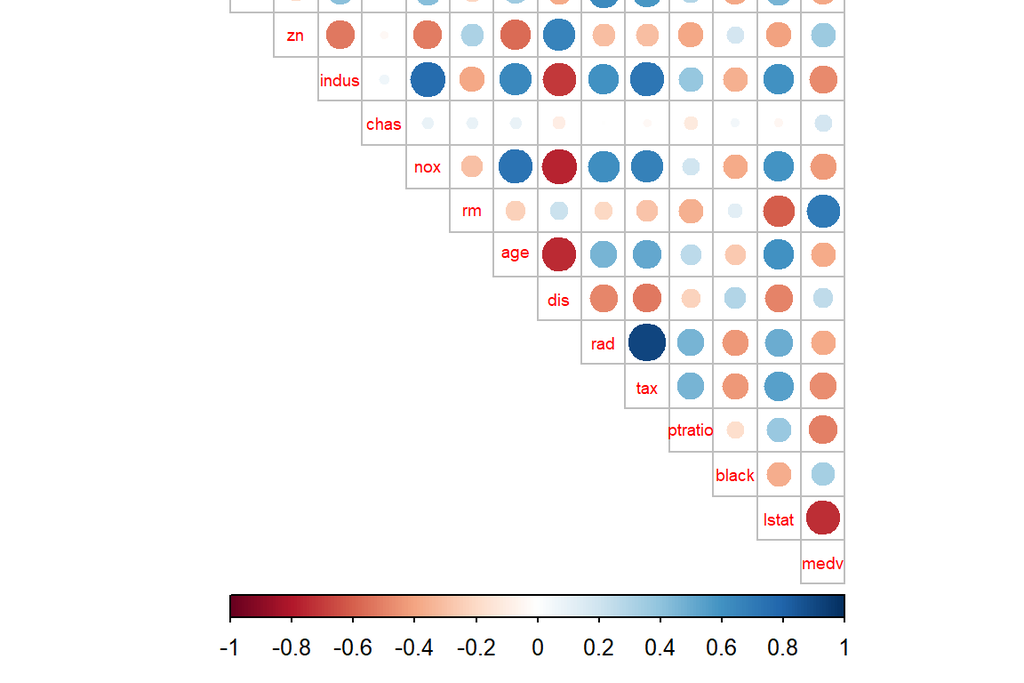

```r
cor_matrix <- cor(Boston) %>% round(digits = 2)
corrplot(cor_matrix, method="circle", type="upper", cl.pos="b", tl.pos="d", tl.cex = 0.6)
```

Visual overview show strong negative correlation between:

*lower status of the population (percent) and median value of owner-occupied homes in $1000s* proportion of owner-occupied units built prior to 1940 and weighted mean of distances to five Boston employment centres *proportion of non-retail business acres per town and weighted mean of distances to five Boston employment centres

These correlations make sense. For example, it is evident that buildings that are old are closer to employment centers.

Additionaly there are strong positive correlation between:

*index of accessibility to radial highways and full-value property-tax rate per $10,000* proportion of non-retail business acres per town and nitrogen oxides concentration (parts per 10 million)

These correlations are also evident. The high way access indicate higher property tax rate and industry provide some NO emissions.

Back to top

## Scaling

```r
boston_scaled <- scale(Boston)
boston_scaled <- as.data.frame(boston_scaled)
summary(boston_scaled)
```

```
##       crim                 zn               indus              chas
##  Min.   :-0.419367   Min.   :-0.48724   Min.   :-1.5563   Min.   :-0.2723
##  1st Qu.:-0.410563   1st Qu.:-0.48724   1st Qu.:-0.8668   1st Qu.:-0.2723
##  Median :-0.390280   Median :-0.48724   Median :-0.2109   Median :-0.2723
##  Mean   : 0.000000   Mean   : 0.00000   Mean   : 0.0000   Mean   : 0.0000
##  3rd Qu.: 0.007389   3rd Qu.: 0.04872   3rd Qu.: 1.0150   3rd Qu.:-0.2723
##  Max.   : 9.924110   Max.   : 3.80047   Max.   : 2.4202   Max.   : 3.6648
##       nox                rm               age               dis
##  Min.   :-1.4644   Min.   :-3.8764   Min.   :-2.3331   Min.   :-1.2658
##  1st Qu.:-0.9121   1st Qu.:-0.5681   1st Qu.:-0.8366   1st Qu.:-0.8049
##  Median :-0.1441   Median :-0.1084   Median : 0.3171   Median :-0.2790
##  Mean   : 0.0000   Mean   : 0.0000   Mean   : 0.0000   Mean   : 0.0000
##  3rd Qu.: 0.5981   3rd Qu.: 0.4823   3rd Qu.: 0.9059   3rd Qu.: 0.6617
##  Max.   : 2.7296   Max.   : 3.5515   Max.   : 1.1164   Max.   : 3.9566
##       rad               tax             ptratio            black
##  Min.   :-0.9819   Min.   :-1.3127   Min.   :-2.7047   Min.   :-3.9033
##  1st Qu.:-0.6373   1st Qu.:-0.7668   1st Qu.:-0.4876   1st Qu.: 0.2049
##  Median :-0.5225   Median :-0.4642   Median : 0.2746   Median : 0.3808
##  Mean   : 0.0000   Mean   : 0.0000   Mean   : 0.0000   Mean   : 0.0000
##  3rd Qu.: 1.6596   3rd Qu.: 1.5294   3rd Qu.: 0.8058   3rd Qu.: 0.4332
##  Max.   : 1.6596   Max.   : 1.7964   Max.   : 1.6372   Max.   : 0.4406
##      lstat              medv
##  Min.   :-1.5296   Min.   :-1.9063
##  1st Qu.:-0.7986   1st Qu.:-0.5989
##  Median :-0.1811   Median :-0.1449
##  Mean   : 0.0000   Mean   : 0.0000
##  3rd Qu.: 0.6024   3rd Qu.: 0.2683
##  Max.   : 3.5453   Max.   : 2.9865
```

```r
quant <- quantile(boston_scaled$crim)
crim <- cut(boston_scaled$crim, breaks = quant, include.lowest = TRUE, labels = c("low","med_low","med_high","high"))
boston_scaled <- dplyr::select(boston_scaled, -crim)
boston_scaled <- cbind(boston_scaled, crim)

# Creating training and testing sets
n <- nrow(boston_scaled)
ind <- sample(n,  size = n * 0.8)
training <- boston_scaled[ind,]
testing <- boston_scaled[-ind,]
```

Back to top

## Fit the linear discriminant

```r
ldamod <- lda(crim ~ ., data = training)
ldamod
```

```
## Call:
## lda(crim ~ ., data = training)
##
## Prior probabilities of groups:
##       low   med_low  med_high      high
## 0.2475248 0.2648515 0.2475248 0.2400990
##
## Group means:
##                   zn      indus        chas        nox          rm        age
## low       0.91527095 -0.9476595 -0.19358706 -0.8714022  0.41104265 -0.8653956
## med_low  -0.07670162 -0.2961420  0.02203357 -0.5672652 -0.10792599 -0.3074822
## med_high -0.37575963  0.1046333  0.20012296  0.3445439  0.08628542  0.4188837
## high     -0.48724019  1.0172187 -0.02879709  1.0643626 -0.47760368  0.8261800
##                 dis        rad        tax    ptratio       black      lstat
## low       0.8771171 -0.6947544 -0.7211892 -0.4903281  0.37840320 -0.7416633
## med_low   0.3560822 -0.5568311 -0.5160058 -0.0822023  0.32698082 -0.1197206
## med_high -0.3724509 -0.4156770 -0.3308301 -0.3115707  0.07194675 -0.0192637
## high     -0.8458720  1.6371072  1.5133254  0.7795879 -0.74380276  0.8940062
##                 medv
## low       0.49626422
## med_low   0.03291337
## med_high  0.19410389
## high     -0.71255308
##
## Coefficients of linear discriminants:
##                  LD1          LD2         LD3
## zn       0.127759778  0.661293224 -0.83743803
## indus   -0.033161897 -0.179959599  0.60150423
## chas     0.002320892 -0.076447848  0.12257167
## nox      0.472232796 -0.709761507 -1.39516174
## rm       0.008805114 -0.005237364 -0.09099469
## age      0.259914463 -0.328985608 -0.11254669
## dis     -0.108515652 -0.157440775  0.24051697
## rad      3.072474971  0.949391606  0.19482115
## tax      0.062855797 -0.017542131  0.13851079
## ptratio  0.123024133  0.007883319 -0.19860162
## black   -0.118266847  0.057138339  0.15275994
## lstat    0.169876479 -0.226388518  0.48581600
## medv     0.057427661 -0.458141632 -0.06990642
##
## Proportion of trace:
##    LD1    LD2    LD3
## 0.9519 0.0362 0.0119
```

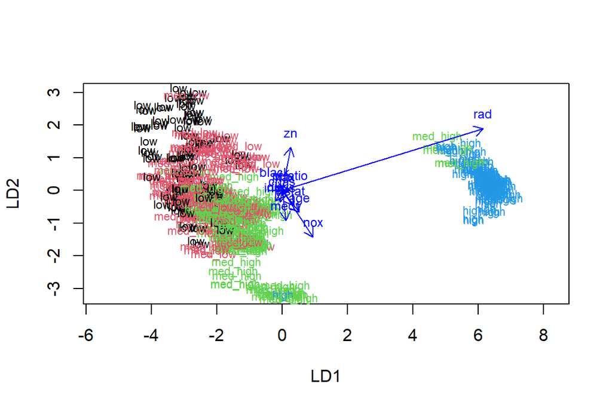

```r
lda.arrows <- function(x, myscale = 1, arrow_heads = 0.1, color = "blue", tex = 0.75, choices = c(1,2)){
  heads <- coef(x)
  arrows(x0 = 0, y0 = 0,
         x1 = myscale * heads[,choices[1]],
         y1 = myscale * heads[,choices[2]], col=color, length = arrow_heads)
  text(myscale * heads[,choices], labels = row.names(heads),
       cex = tex, col=color, pos=3)
}

classes <- as.numeric(training$crim)

plot(ldamod, dimen = 2, col = classes, pch = classes)
lda.arrows(ldamod, myscale = 2)
```

There is a lot to understand in this figure for me. Apparently variable rad is important in this data.

Back to top

## Class prediction

Removing the old data that are next predicted.

```r
orig_class <- testing$crim
testing <- dplyr::select(testing, -crim)
```

Then the prediction itself.

```r
pred <- predict(ldamod, newdata = testing)
table(correct = orig_class, predicted = pred$class)
```

```
##           predicted
## correct    low med_low med_high high
##   low       15      10        2    0
##   med_low    1      11        7    0
##   med_high   0       7       18    1
##   high       0       0        0   30
```

Back to top

## K-means

```r
data('Boston')
boston_scaled2 <- scale(Boston)
boston_scaled2 <- as.data.frame(boston_scaled2)

# some distances
dist_eu <- dist(boston_scaled2)
summary(dist_eu)
```

```
##    Min. 1st Qu.  Median    Mean 3rd Qu.    Max.
##  0.1343  3.4625  4.8241  4.9111  6.1863 14.3970
```

Plotting is not very efficient with all the variables so only plotting nox, rm, age, dis, rad and tax variables.

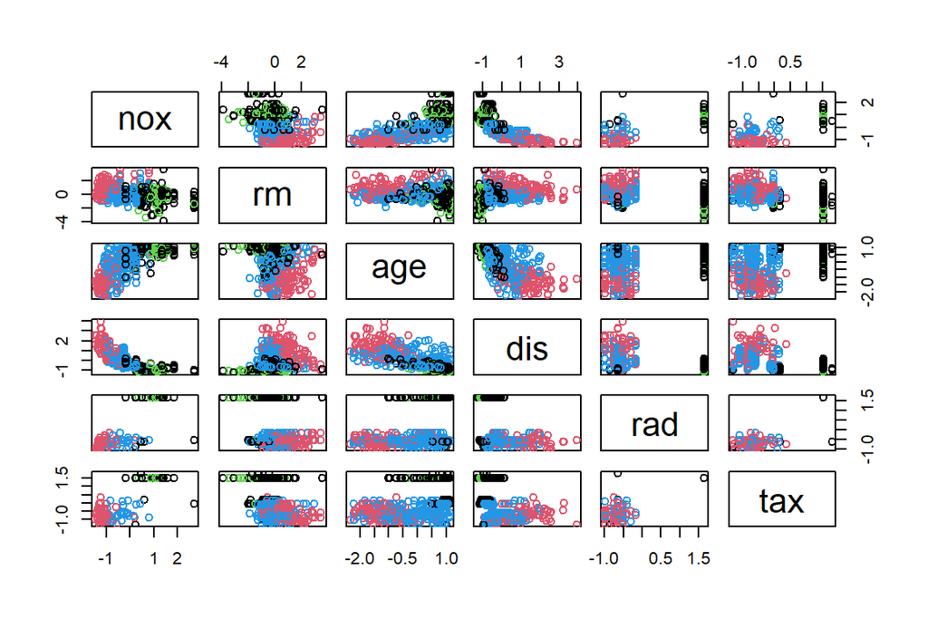

```r
km <-kmeans(boston_scaled2, centers = 4)
pairs(boston_scaled2[,5:10], col = km$cluster)
```

Next trying to figure out best number of clusters.

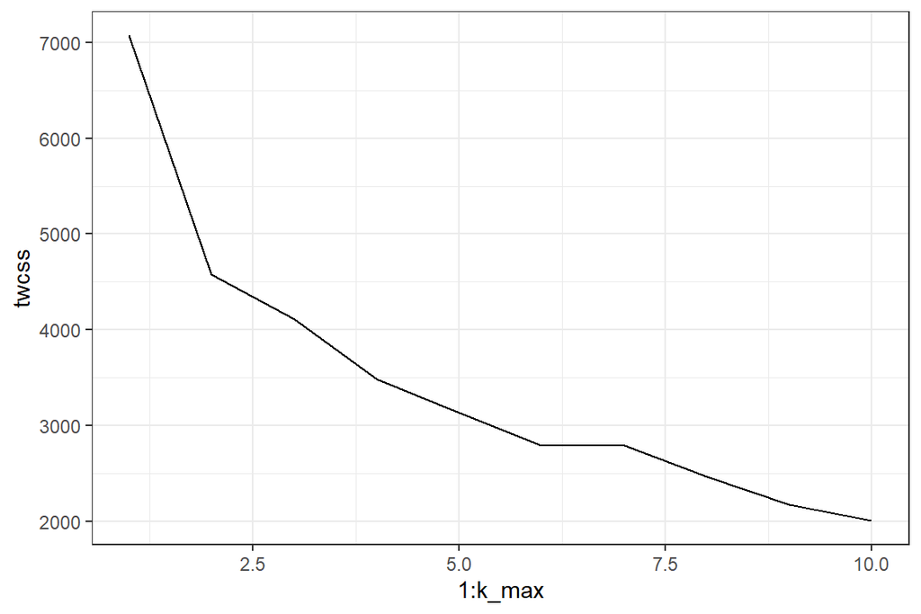

```r
set.seed(17)
k_max <- 10
twcss <- sapply(1:k_max, function(k){kmeans(boston_scaled2, k)$tot.withinss})
qplot(x = 1:k_max, y = twcss, geom = 'line') + theme_bw()
```

This exploration indicates that increasing number of clusters over 2 wont give dramatically better results. Therefor 2 clusters will give the best results.

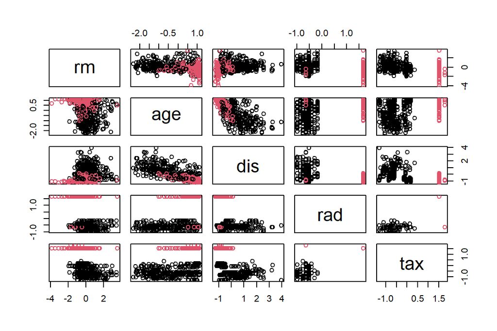

```r
km <-kmeans(Boston, centers = 2)
pairs(boston_scaled2[,6:10], col = km$cluster)
```

The best separation between groups can be found in variables tax (property tax-rate) and rad (distance to the radial highways).

All the variables were plotted at first but they didn’t provide any further information and only made figures harder to read so they are not shown.

Back to top

# Chapter 5: Dimensionality reduction techniques

## Overview of the data

```r
human <- read.csv("data/human.csv", row.names = 1)
summary(human)
```

```
##    edu2_ratio       lab_ratio         Exp_Life        Exp_Educ
##  Min.   :0.1717   Min.   :0.1857   Min.   :49.00   Min.   : 5.40
##  1st Qu.:0.7264   1st Qu.:0.5984   1st Qu.:66.30   1st Qu.:11.25
##  Median :0.9375   Median :0.7535   Median :74.20   Median :13.50
##  Mean   :0.8529   Mean   :0.7074   Mean   :71.65   Mean   :13.18
##  3rd Qu.:0.9968   3rd Qu.:0.8535   3rd Qu.:77.25   3rd Qu.:15.20
##  Max.   :1.4967   Max.   :1.0380   Max.   :83.50   Max.   :20.20
##       GNI           Mort_ratio          ABR              PRP
##  Min.   :   581   Min.   :   1.0   Min.   :  0.60   Min.   : 0.00
##  1st Qu.:  4198   1st Qu.:  11.5   1st Qu.: 12.65   1st Qu.:12.40
##  Median : 12040   Median :  49.0   Median : 33.60   Median :19.30
##  Mean   : 17628   Mean   : 149.1   Mean   : 47.16   Mean   :20.91
##  3rd Qu.: 24512   3rd Qu.: 190.0   3rd Qu.: 71.95   3rd Qu.:27.95
##  Max.   :123124   Max.   :1100.0   Max.   :204.80   Max.   :57.50
```

Here are the distribution plots.

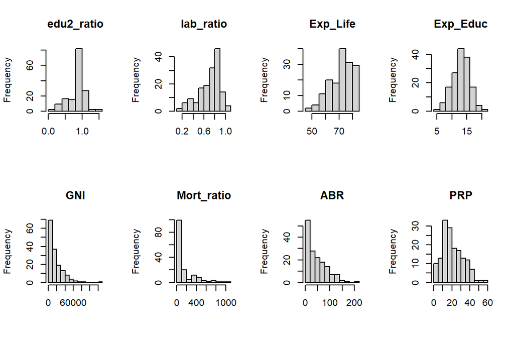

Th variables in human data are definitely not normally distributed.

```r
cor_matrix<-cor(human) %>% round(digits = 2)
cor_matrix
```

```
##            edu2_ratio lab_ratio Exp_Life Exp_Educ   GNI Mort_ratio   ABR   PRP
## edu2_ratio       1.00      0.01     0.58     0.59  0.43      -0.66 -0.53  0.08
## lab_ratio        0.01      1.00    -0.14     0.05 -0.02       0.24  0.12  0.25
## Exp_Life         0.58     -0.14     1.00     0.79  0.63      -0.86 -0.73  0.17
## Exp_Educ         0.59      0.05     0.79     1.00  0.62      -0.74 -0.70  0.21
## GNI              0.43     -0.02     0.63     0.62  1.00      -0.50 -0.56  0.09
## Mort_ratio      -0.66      0.24    -0.86    -0.74 -0.50       1.00  0.76 -0.09
## ABR             -0.53      0.12    -0.73    -0.70 -0.56       0.76  1.00 -0.07
## PRP              0.08      0.25     0.17     0.21  0.09      -0.09 -0.07  1.00
```

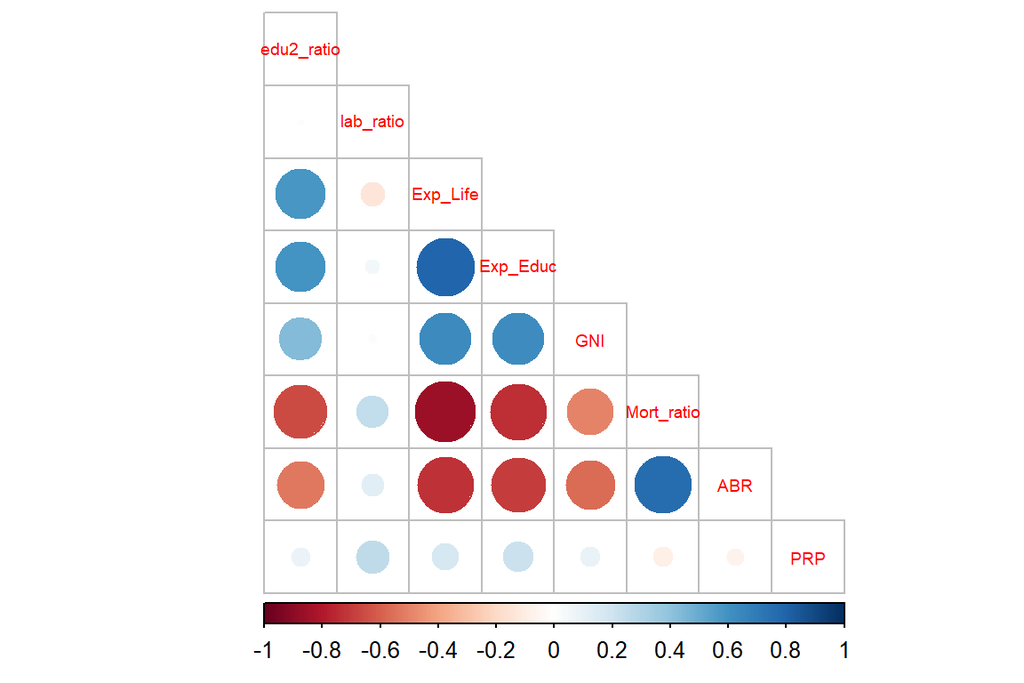

```r
corrplot(cor_matrix, method="circle", type="lower", cl.pos="b", tl.pos="d", tl.cex = 0.6)
```

There is some clear positive and negative correlations. Negative correlation can be seen between life expectancy at birth and maternal mortality ratio (r =-0.86) plus expected years of schooling and maternal mortality ratio (r = -0.74). Additionally, there is positive correlation between Exp_Life and Exp_Educ (r = 0.79) plus Mort_ratio and ABR (r = 0.76).

Back to top

## PCA with non standardized values

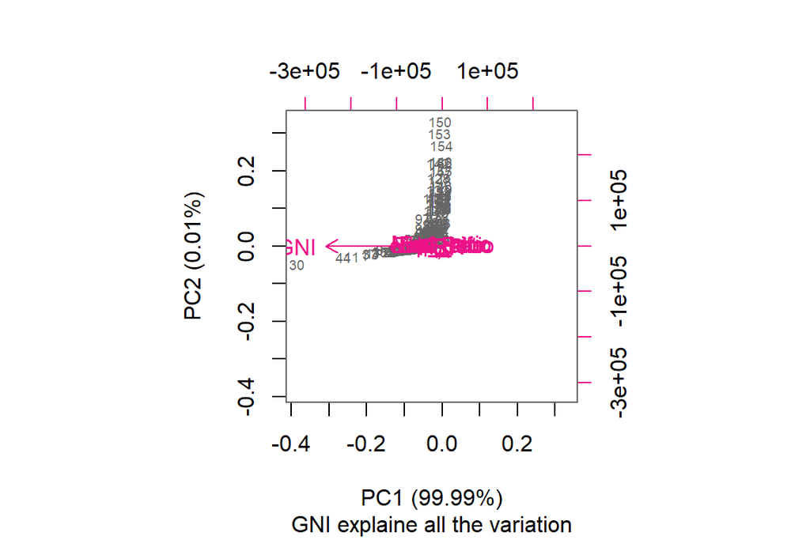

```r
pca <- prcomp(human, center = F, scale. = F)
summa <- summary(pca)
pca_names <- round(100*summa$importance[2,], digits = 2)
biplot(pca, choices = 1:2, cex = c(0.6, 1), col = c("grey40", "deeppink2"),
       xlabs = c(1:nrow(human)), xlab = paste0("PC1 (", pca_names[1], "%)"),
       ylab = paste0("PC2 (", pca_names[2], "%)"),
       sub = "GNI explaine all the variation")
```

Results indicate that variable GNI explains all the variation in the data although it is most likely not true.

Back to top

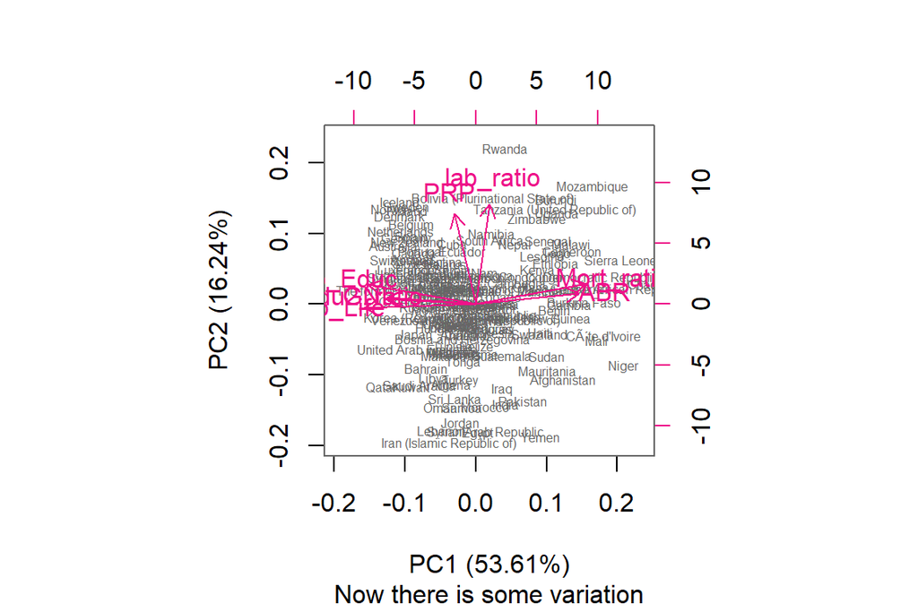

```r
pca <- prcomp(human, center = T, scale. = T)
summa <- summary(pca)
pca_names <- round(100*summa$importance[2,], digits = 2)
biplot(pca, choices = 1:2, cex = c(0.5, 1), col = c("grey40", "deeppink2"),
       #xlabs = c(1:nrow(human)),
       xlab = paste0("PC1 (", pca_names[1], "%)"),
       ylab = paste0("PC2 (", pca_names[2], "%)"),
       sub = "Now there is some variation")
```

As expected, result differ quite much between PCA with non standardized values and PCA with standardized values. Difference can be explained with mathematics. The PCA only understand standard deviation and scales and thus say that GNI with biggest scale and SD explains all the variance in the data. PCA does not have brains so it does not understand are variables having the same SD or scale.

Variables causing majority of variation are Exp_Educ, edu2_ratio, Exp_Life, Mort_ratio, and ABR.

Back to top

## Personal interpretation

The second PCA shown here explains 69% of the variation in the data which is good number. PC1 covers 54 percentage of it. The first PC is inversely associated (PC is slower when variable is higher) with education and expected life span. Also, it is directly associated (PC is higher when variable is higher) with maternal mortal and adolescent birth rate. These finding can be found to be the opposite for each other as typically when the education is higher, the maternal mortality rate is lower.

PC2 explain about 16 percentage of variation in the data. It is directly associated with female participation in the society meaning the portion of labor force and percentage of females in the parliament. Basically, if PC2 value is high for some country it means that females are capable to affect to the society in country under consideration.

“lab_ratio” = Labo2.F / Labo2.M “PRP” = Percetange of female representatives in parliament

The second PC explained 16% of variation in the data. It associated positively with female participation in the society including proportions of females in the labor force and parliament. This PC indicates how well females are able to affect the society via working life and politics.

Back to top